# Working with Data Structures

M2 ICA2

# 1 Introduction

Today we will investigate a data set from (http://www.gapminder.org), a site which contains a wealth of data and visualizations related to health, wealth, population, etc. of countries of the world. Typical datasets from (http://www.gapminder.org) are somewhat messy, with a lot of missing observations, so today we will work with data extracted from the more complete data sets by Jenny Bryan at UBC. First we load the data into R.This dataset can be extracted from the “gapminder” package in CRAN. As such initially we need to install and call the package. This dataset can aslo be as a .RData file in the same working directory as the .Rmd file and can be called from there.

```r
#install.packages("gapminder")
library("gapminder")
gapminder <- system.file("extdata", "gapminder.tsv", package = "gapminder")
gapminder <- read.delim(gapminder)
ls(gapminder)
```

```
[1] "continent" "country"   "gdpPercap" "lifeExp"   "pop"       "year"
```

```r
head(gapminder)
```

|  | country | continent | year | lifeExp | pop | gdpPercap |
| --- | --- | --- | --- | --- | --- | --- |
| 1 | Afghanistan | Asia | 1952 | 28.801 | 8425333 | 779.4453 |
| 2 | Afghanistan | Asia | 1957 | 30.332 | 9240934 | 820.8530 |
| 3 | Afghanistan | Asia | 1962 | 31.997 | 10267083 | 853.1007 |
| 4 | Afghanistan | Asia | 1967 | 34.020 | 11537966 | 836.1971 |
| 5 | Afghanistan | Asia | 1972 | 36.088 | 13079460 | 739.9811 |
| 6 | Afghanistan | Asia | 1977 | 38.438 | 14880372 | 786.1134 |

Function `ls` returns a vector of character strings giving the names of the objects in the specified environment.

# 2 Dataframe

The `str` function reports on the structure of an object in R. It’s often useful to use `str` when working with a new dataset.

```r
str(gapminder)
```

```
'data.frame':   1704 obs. of  6 variables:
 $ country  : chr  "Afghanistan" "Afghanistan" "Afghanistan" "Afghanistan" ...
 $ continent: chr  "Asia" "Asia" "Asia" "Asia" ...
 $ year     : int  1952 1957 1962 1967 1972 1977 1982 1987 1992 1997 ...
 $ lifeExp  : num  28.8 30.3 32 34 36.1 ...
 $ pop      : int  8425333 9240934 10267083 11537966 13079460 14880372 12881816 13867957 16317921 22227415 ...
 $ gdpPercap: num  779 821 853 836 740 ...
```

How would you extract the third row of the data frame?

```r
#Extract the third row here
gapminder[3,]
```

|  | country | continent | year | lifeExp | pop | gdpPercap |
| --- | --- | --- | --- | --- | --- | --- |
| 3 | Afghanistan | Asia | 1962 | 31.997 | 10267083 | 853.1007 |

How would you extract the first 50 elements of the variable `year`?

```r
#Extract the first 50 elements of the variable year here

year_50 <- gapminder$year[1:50]

year_50
```

```
 [1] 1952 1957 1962 1967 1972 1977 1982 1987 1992 1997 2002 2007 1952 1957 1962
[16] 1967 1972 1977 1982 1987 1992 1997 2002 2007 1952 1957 1962 1967 1972 1977
[31] 1982 1987 1992 1997 2002 2007 1952 1957 1962 1967 1972 1977 1982 1987 1992
[46] 1997 2002 2007 1952 1957
```

There are a lot of repeated values in `year`. The `unique` function reports on the unique values in a variable.

```r
#Display the unique values in the variable year here

year_unique <- unique(gapminder$year)
year_unique
```

```
 [1] 1952 1957 1962 1967 1972 1977 1982 1987 1992 1997 2002 2007
```

Next we will work with two particular years, 1952 and 2002, from the dataset. We will use the `subset` function to extract data frames containing data from these two years. Here is how to extract the data for 1952:

```r
gapminder1952 <- subset(gapminder, year == 1952)
str(gapminder1952)
```

```
'data.frame':   142 obs. of  6 variables:
 $ country  : chr  "Afghanistan" "Albania" "Algeria" "Angola" ...
 $ continent: chr  "Asia" "Europe" "Africa" "Africa" ...
 $ year     : int  1952 1952 1952 1952 1952 1952 1952 1952 1952 1952 ...
 $ lifeExp  : num  28.8 55.2 43.1 30 62.5 ...
 $ pop      : int  8425333 1282697 9279525 4232095 17876956 8691212 6927772 120447 46886859 8730405 ...
 $ gdpPercap: num  779 1601 2449 3521 5911 ...
```

Note that to specify that a variable is equal to a particular value, we use `==`. Next extract the data for 2002, and assign the resulting data frame to an object named `gapminder2002`.

```r
#Create the data frame here
gapminder2002 <- subset(gapminder, year == 2002)
gapminder2002
```

|  | country | continent | year | lifeExp | pop | gdpPercap |
| --- | --- | --- | --- | --- | --- | --- |
| 11 | Afghanistan | Asia | 2002 | 42.129 | 25268405 | 726.7341 |
| 23 | Albania | Europe | 2002 | 75.651 | 3508512 | 4604.2117 |
| 35 | Algeria | Africa | 2002 | 70.994 | 31287142 | 5288.0404 |
| 47 | Angola | Africa | 2002 | 41.003 | 10866106 | 2773.2873 |
| 59 | Argentina | Americas | 2002 | 74.340 | 38331121 | 8797.6407 |
| 71 | Australia | Oceania | 2002 | 80.370 | 19546792 | 30687.7547 |
| 83 | Austria | Europe | 2002 | 78.980 | 8148312 | 32417.6077 |
| 95 | Bahrain | Asia | 2002 | 74.795 | 656397 | 23403.5593 |
| 107 | Bangladesh | Asia | 2002 | 62.013 | 135656790 | 1136.3904 |
| 119 | Belgium | Europe | 2002 | 78.320 | 10311970 | 30485.8838 |

[output cut: 132 more lines]

5. Create comparison boxplots for between continent and life expectancy for year 2002. An example from the 1952 data is given below.

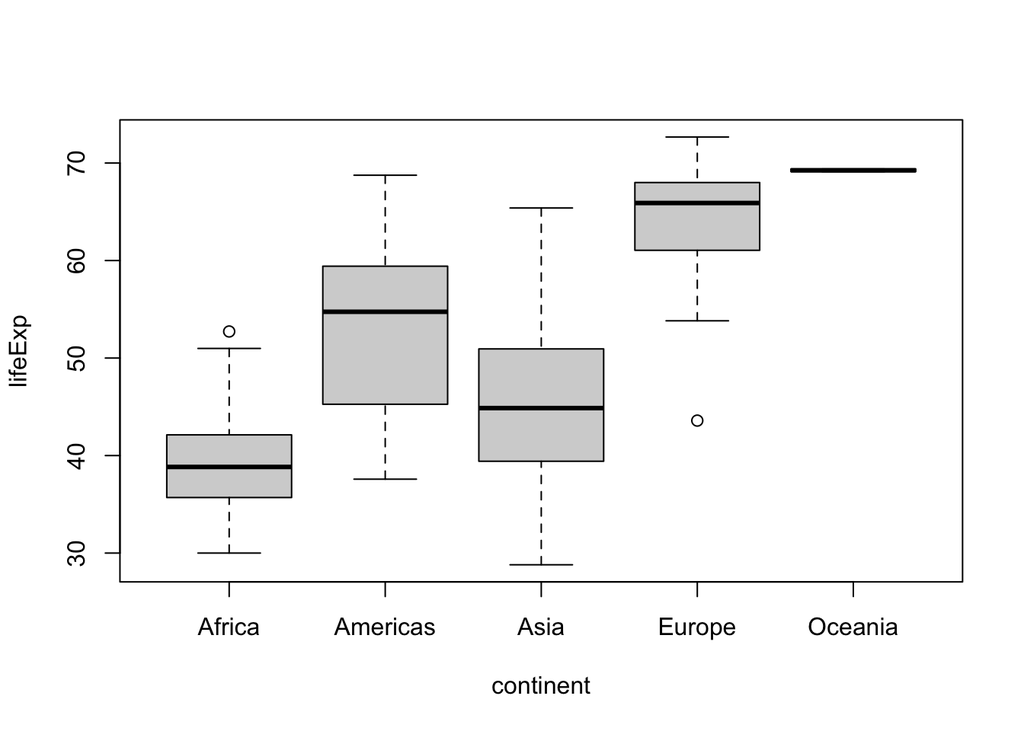

**Draw similar boxplots for 2002.**

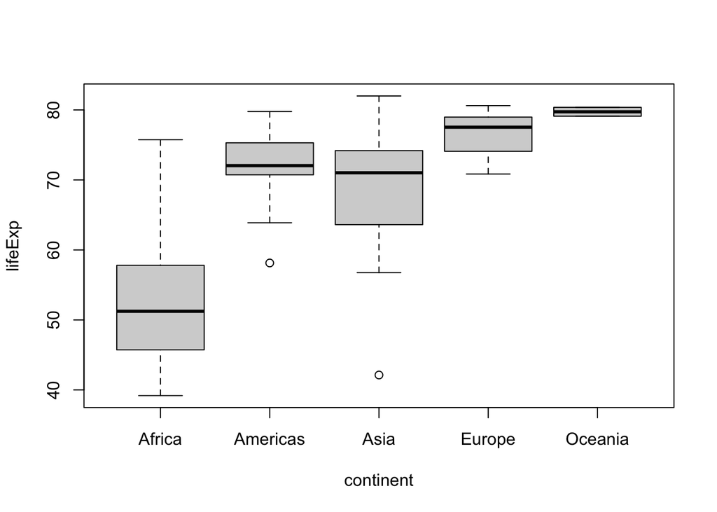

6. From the boxplots for 2002, what do you notice? Which continent has the largest median life expectancy? Which continent has the largest inter-quartile range with regards to life expectancy?

*I noticed that some of the box plots given data shurnk and some grew, for america the variables decresed only giving not a small range of life expectancy.* The largest median life expectancy is located in `oceania` * `Africa` has the largest inter-quartile range

7. Compute a few summary statistics for life expectancy and GDP in 1952. Compare these with the same statistics from 2002. Should we compare raw GDP numbers across time such as this?

```r
print("Summary of 1952 life")
```

```
[1] "Summary of 1952 life"
```

```r
gap_1952 = gapminder$lifeExp[gapminder$year == 1952]
summary(gap_1952)
```

```
   Min. 1st Qu.  Median    Mean 3rd Qu.    Max.
  28.80   39.06   45.14   49.06   59.77   72.67
```

```r
print("Summary of 1952 GDP")
```

```
[1] "Summary of 1952 GDP"
```

```r
gap_1952_gdp = gapminder$gdpPercap[gapminder$year == 1952]

summary(gap_1952_gdp)
```

```
    Min.  1st Qu.   Median     Mean  3rd Qu.     Max.
   298.9    864.8   1968.5   3725.3   3913.5 108382.4
```

```r
print("Summary of 2002 life")
```

```
[1] "Summary of 2002 life"
```

```r
gap_2002 = gapminder$lifeExp[gapminder$year == 2002]
summary(gap_2002)
```

```
   Min. 1st Qu.  Median    Mean 3rd Qu.    Max.
  39.19   55.52   70.83   65.69   75.46   82.00
```

```r
print("Summary of 2002 GDP")
```

```
[1] "Summary of 2002 GDP"
```

```r
gap_2002_gdp = gapminder$gdpPercap[gapminder$year == 2002]

summary(gap_2002_gdp)
```

```
   Min. 1st Qu.  Median    Mean 3rd Qu.    Max.
  241.2  1409.6  5319.8  9917.9 13359.5 44684.0
```

8. Choose a country of interest. Create a data frame which only contains data from that country. Draw scatter plots of life expectancy, and of the GDP, both versus the year. To add some customization such as color, connecting the points, and changing the point style see https://www.statmethods.net/advgraphs/parameters.html.

```r
#Calculate the median life expectancies here

jap_df = subset(gapminder, country == "Japan")
jap_df
```

|  | country | continent | year | lifeExp | pop | gdpPercap |
| --- | --- | --- | --- | --- | --- | --- |
| 793 | Japan | Asia | 1952 | 63.030 | 86459025 | 3216.956 |
| 794 | Japan | Asia | 1957 | 65.500 | 91563009 | 4317.694 |
| 795 | Japan | Asia | 1962 | 68.730 | 95831757 | 6576.649 |
| 796 | Japan | Asia | 1967 | 71.430 | 100825279 | 9847.789 |
| 797 | Japan | Asia | 1972 | 73.420 | 107188273 | 14778.786 |
| 798 | Japan | Asia | 1977 | 75.380 | 113872473 | 16610.377 |
| 799 | Japan | Asia | 1982 | 77.110 | 118454974 | 19384.106 |
| 800 | Japan | Asia | 1987 | 78.670 | 122091325 | 22375.942 |
| 801 | Japan | Asia | 1992 | 79.360 | 124329269 | 26824.895 |
| 802 | Japan | Asia | 1997 | 80.690 | 125956499 | 28816.585 |

[output cut: 2 more lines]

```r
jap_exp = jap_df$lifeExp
jap_year = jap_df$year

jap_gdp = jap_df$gdpPercap
```

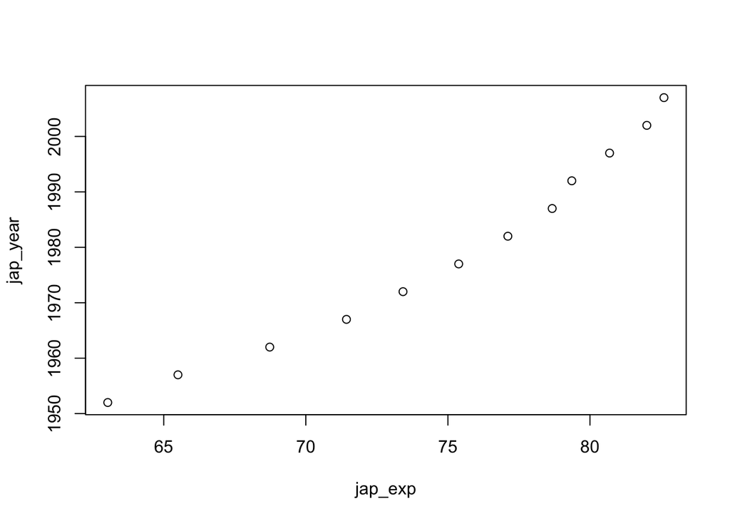

```r
plot(jap_exp,jap_year)
```

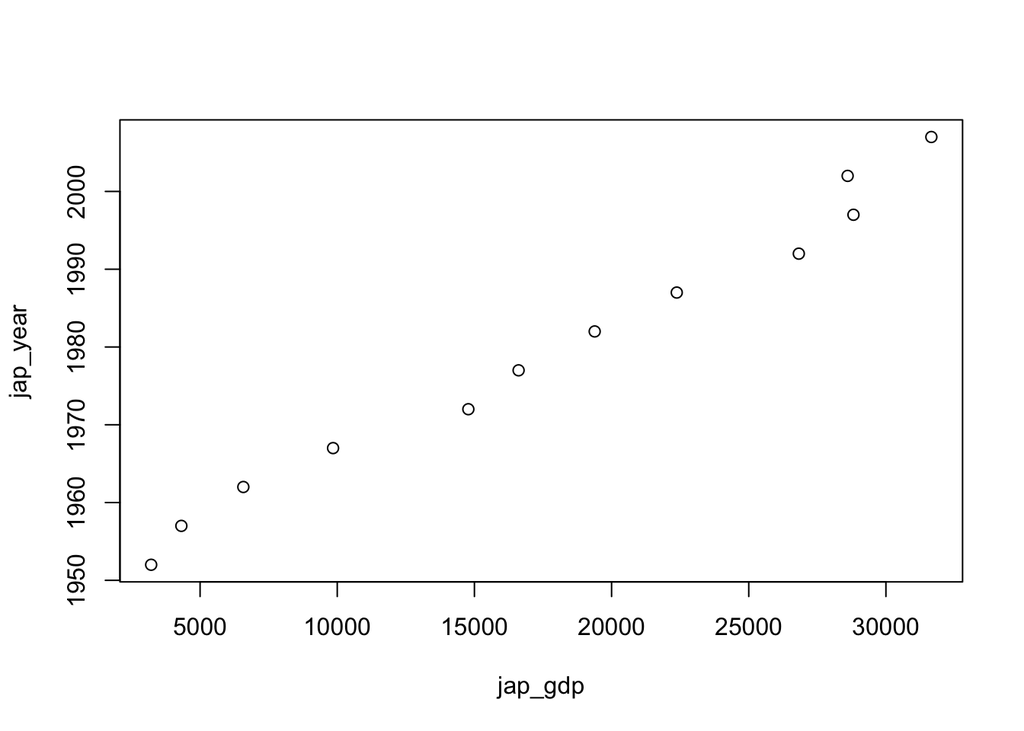

```r
plot(jap_gdp,jap_year)
```

9. Next calculate the median life expectancy, for both 1952 and 2002.

What do you notice?

```r
jap_1952 = jap_df$lifeExp[jap_df$year == 1952]
jap_2002 = jap_df$lifeExp[jap_df$year == 2002]

median(jap_1952)
```

```
[1] 63.03
```

```r
median(jap_2002)
```

```
[1] 82
```

10. Next calculate the mean and median GDP for both years.

```r
#Calculate the mean and median GDPs here.

jap_1952 = jap_df$gdpPercap[jap_df$year == 1952]
jap_2002 = jap_df$gdpPercap[jap_df$year == 2002]

median(jap_1952)
```

```
[1] 3216.956
```

```r
median(jap_2002)
```

```
[1] 28604.59
```

Again, what do you notice?

Choose a country of interest. Create a data frame which only contains data from that country, and then draw scatter plots of the life expectancy, and of the GDP, both versus the year.

```r
#Create the data frame and draw the scatter plots here.

jam_df = subset(gapminder, country == "Jamaica")
jam_df
```

|  | country | continent | year | lifeExp | pop | gdpPercap |
| --- | --- | --- | --- | --- | --- | --- |
| 781 | Jamaica | Americas | 1952 | 58.530 | 1426095 | 2898.531 |
| 782 | Jamaica | Americas | 1957 | 62.610 | 1535090 | 4756.526 |
| 783 | Jamaica | Americas | 1962 | 65.610 | 1665128 | 5246.108 |
| 784 | Jamaica | Americas | 1967 | 67.510 | 1861096 | 6124.703 |
| 785 | Jamaica | Americas | 1972 | 69.000 | 1997616 | 7433.889 |
| 786 | Jamaica | Americas | 1977 | 70.110 | 2156814 | 6650.196 |
| 787 | Jamaica | Americas | 1982 | 71.210 | 2298309 | 6068.051 |
| 788 | Jamaica | Americas | 1987 | 71.770 | 2326606 | 6351.237 |
| 789 | Jamaica | Americas | 1992 | 71.766 | 2378618 | 7404.924 |
| 790 | Jamaica | Americas | 1997 | 72.262 | 2531311 | 7121.925 |

[output cut: 2 more lines]

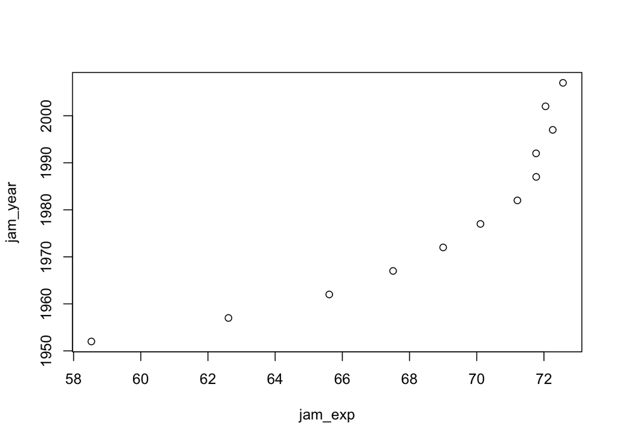

```r
jam_exp = jam_df$lifeExp
jam_year = jam_df$year

jam_gdp = jam_df$gdpPercap

plot(jam_exp,jam_year)
```

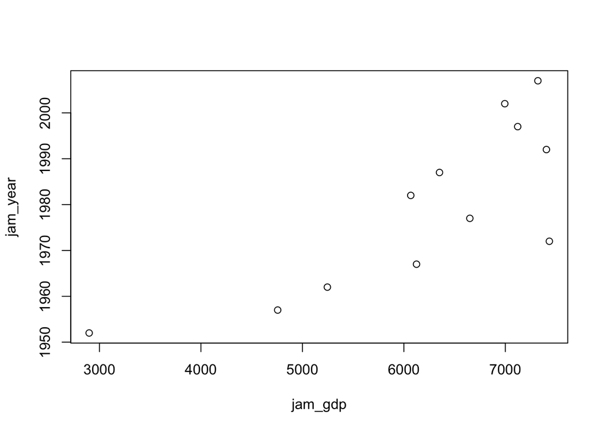

```r
plot(jam_gdp,jam_year)
```

# 3 Logical subsetting

Subsetting with logical vectors is an essential skill. When a vector, say x, is subset with a logical vector, the components of x are returned wherever a TRUE value component exists in the logical vector. Below are some examples. Think about what is happening in each example. Recall that we can combine conditions with the operators `&` and `|` which represent “and” and “or”.

```r
mean(gapminder$pop[gapminder$country == "France"])
```

```
[1] 52952564
```

```r
unique(gapminder$country[gapminder$continent == "Africa"])
```

```
 [1] "Algeria"                  "Angola"
 [3] "Benin"                    "Botswana"
 [5] "Burkina Faso"             "Burundi"
 [7] "Cameroon"                 "Central African Republic"
 [9] "Chad"                     "Comoros"
[11] "Congo, Dem. Rep."         "Congo, Rep."
[13] "Cote d'Ivoire"            "Djibouti"
[15] "Egypt"                    "Equatorial Guinea"
[17] "Eritrea"                  "Ethiopia"
[19] "Gabon"                    "Gambia"
[21] "Ghana"                    "Guinea"
[23] "Guinea-Bissau"            "Kenya"
[25] "Lesotho"                  "Liberia"
[27] "Libya"                    "Madagascar"
[29] "Malawi"                   "Mali"
[31] "Mauritania"               "Mauritius"
[33] "Morocco"                  "Mozambique"
[35] "Namibia"                  "Niger"
[37] "Nigeria"                  "Reunion"
[39] "Rwanda"                   "Sao Tome and Principe"
[41] "Senegal"                  "Sierra Leone"
[43] "Somalia"                  "South Africa"
[45] "Sudan"                    "Swaziland"
[47] "Tanzania"                 "Togo"
[49] "Tunisia"                  "Uganda"
[51] "Zambia"                   "Zimbabwe"
```

```r
gapminder$country[(gapminder$pop > 150000000) & (gapminder$year == 1992)]
```

```
[1] "Brazil"        "China"         "India"         "Indonesia"
[5] "United States"
```

Operator `%in%` returns a logical vector indicating if there is a match or not for its left operand. Consider the example below

```r
x <- 5:10
y <- c(3, 5, 6, 9, 12, 15)

x %in% y
```

```
[1]  TRUE  TRUE FALSE FALSE  TRUE FALSE
```

```r
y %in% x
```

```
[1] FALSE  TRUE  TRUE  TRUE FALSE FALSE
```

Subsetting also can be used to change values of existing `R` objects as in the following example. Remove the chunk option `eval = FALSE` to see the example’s result in your knitted HTML file.

```r
dd <-  data.frame(x = c("dog", "cat", "oink", "pig", "oink", "cat", "dog"),
                y = c("dog", "cat", "cat", "pig", "cow", "dog", "dog"),
                stringsAsFactors = FALSE)
dd

dd$x[dd$x == "oink"] <- "pig"
dd

dd$same <- rep("no", dim(dd)[1])
dd

dd$same[dd$x == dd$y] <- "yes"
dd
```

## 3.1 Exercises

1. Extract the population values of all countries whose life expectancy is more than 70 years for the year 1967.
2. For the year 2007, how many countries had a life expectancy of at least 75?
3. Add a variable called `G8` to the `gapminder` data frame, which will be equal to 1 or 0 depending on whether the country is in the G8 group of nations: France, Germany, Italy, the United Kingdom, Japan, the United States, Canada, and Russia.
4. Create a plot of your choice that involves countries of the G8.

```r
# 1
life_70 = gapminder$lifeExp > 70
gap_1957 = gapminder$year == 1967

life_more = life_70[gap_1957]

life_pop = gapminder$pop[life_more]
life_pop
```

```
  [1]   14880372   12881816   22227415    1984060    3326498   29072015
  [7]   31287142    8735988   12420476   19610538   36203463   10794968
 [13]   11872264   13177000   15184200     377967     454612     708573
 [19]  113704579    9856303   10311970    2151895    2427334    3211738
 [25]    3593918    3585000    3819000    4338977     474639     970347
 [31]  142938076  155975974    8892098    8066057    7322858    7586551
 [37]    2445618    2667518    2961915    3529983    7021028    7959865
 [43]   14195809   25201900    1927260    3265124    2682462    2894855
 [49]   10238807    6377619  637408000  665770000  943455000 1318683096
 [55]   22542890     304739     348643   23007669   35481645   47798986
 [61]    1536769    3328795    3800610     926317    1345187    4076557
 [67]    4174366    4484310    8831348    9620282   10303704   10256295
 [73]   10228744    5283663    5374693     496374    2491346    4049146
 [79]    7992357    4681707   31681188   34807417    2747687    4282586
 [85]    4842194     259864     387838     439971     495627    1438760
```

[output cut: 35 more lines]

```r
life_75 = gapminder$country[gapminder$lifeExp >= 75]
length(life_75)
```

```
[1] 173
```

# 4 References

1. https://www.gapminder.org/data/
2. https://www.statmethods.net/advgraphs/parameters.html